# FEATURIZATION

### IMPORTING THE LIBRARIES

```python
import pandas as pd
import numpy as np
import matplotlib.pyplot as plt
%matplotlib inline
import seaborn as sns
```

### LOADING THE DATASET.

```python
concrete = pd.read_csv("C:/Users/HP/Downloads/concrete.csv")
concrete
```

|  | cement | slag | ash | water | superplastic | coarseagg | fineagg | age | strength |
| --- | --- | --- | --- | --- | --- | --- | --- | --- | --- |
| 0 | 141.3 | 212.0 | 0.0 | 203.5 | 0.0 | 971.8 | 748.5 | 28 | 29.89 |
| 1 | 168.9 | 42.2 | 124.3 | 158.3 | 10.8 | 1080.8 | 796.2 | 14 | 23.51 |
| 2 | 250.0 | 0.0 | 95.7 | 187.4 | 5.5 | 956.9 | 861.2 | 28 | 29.22 |
| 3 | 266.0 | 114.0 | 0.0 | 228.0 | 0.0 | 932.0 | 670.0 | 28 | 45.85 |
| 4 | 154.8 | 183.4 | 0.0 | 193.3 | 9.1 | 1047.4 | 696.7 | 28 | 18.29 |
| ... | ... | ... | ... | ... | ... | ... | ... | ... | ... |
| 1025 | 135.0 | 0.0 | 166.0 | 180.0 | 10.0 | 961.0 | 805.0 | 28 | 13.29 |
| 1026 | 531.3 | 0.0 | 0.0 | 141.8 | 28.2 | 852.1 | 893.7 | 3 | 41.30 |
| 1027 | 276.4 | 116.0 | 90.3 | 179.6 | 8.9 | 870.1 | 768.3 | 28 | 44.28 |
| 1028 | 342.0 | 38.0 | 0.0 | 228.0 | 0.0 | 932.0 | 670.0 | 270 | 55.06 |
| 1029 | 540.0 | 0.0 | 0.0 | 173.0 | 0.0 | 1125.0 | 613.0 | 7 | 52.61 |

1030 rows × 9 columns

### COLUMN DESCRIPTION OF THE DATA.

```python
concrete.columns
```

```
Index(['cement', 'slag', 'ash', 'water', 'superplastic', 'coarseagg',
       'fineagg', 'age', 'strength'],
      dtype='object')
```

```python
concrete.head(10)
```

|  | cement | slag | ash | water | superplastic | coarseagg | fineagg | age | strength |
| --- | --- | --- | --- | --- | --- | --- | --- | --- | --- |
| 0 | 141.3 | 212.0 | 0.0 | 203.5 | 0.0 | 971.8 | 748.5 | 28 | 29.89 |
| 1 | 168.9 | 42.2 | 124.3 | 158.3 | 10.8 | 1080.8 | 796.2 | 14 | 23.51 |
| 2 | 250.0 | 0.0 | 95.7 | 187.4 | 5.5 | 956.9 | 861.2 | 28 | 29.22 |
| 3 | 266.0 | 114.0 | 0.0 | 228.0 | 0.0 | 932.0 | 670.0 | 28 | 45.85 |
| 4 | 154.8 | 183.4 | 0.0 | 193.3 | 9.1 | 1047.4 | 696.7 | 28 | 18.29 |
| 5 | 255.0 | 0.0 | 0.0 | 192.0 | 0.0 | 889.8 | 945.0 | 90 | 21.86 |
| 6 | 166.8 | 250.2 | 0.0 | 203.5 | 0.0 | 975.6 | 692.6 | 7 | 15.75 |
| 7 | 251.4 | 0.0 | 118.3 | 188.5 | 6.4 | 1028.4 | 757.7 | 56 | 36.64 |
| 8 | 296.0 | 0.0 | 0.0 | 192.0 | 0.0 | 1085.0 | 765.0 | 28 | 21.65 |
| 9 | 155.0 | 184.0 | 143.0 | 194.0 | 9.0 | 880.0 | 699.0 | 28 | 28.99 |

```python
concrete.shape
```

```
(1030, 9)
```

### DATATYPES OF THE ATTRIBUTES.

```python
concrete.dtypes
```

```
cement          float64
slag            float64
ash             float64
water           float64
superplastic    float64
coarseagg       float64
fineagg         float64
age               int64
strength        float64
dtype: object
```

### FIVE NUMBER SUMMARY OF THE DATASET.

```python
concrete.describe().transpose()
```

|  | count | mean | std | min | 25% | 50% | 75% | max |
| --- | --- | --- | --- | --- | --- | --- | --- | --- |
| cement | 1030.0 | 281.167864 | 104.506364 | 102.00 | 192.375 | 272.900 | 350.000 | 540.0 |
| slag | 1030.0 | 73.895825 | 86.279342 | 0.00 | 0.000 | 22.000 | 142.950 | 359.4 |
| ash | 1030.0 | 54.188350 | 63.997004 | 0.00 | 0.000 | 0.000 | 118.300 | 200.1 |
| water | 1030.0 | 181.567282 | 21.354219 | 121.80 | 164.900 | 185.000 | 192.000 | 247.0 |
| superplastic | 1030.0 | 6.204660 | 5.973841 | 0.00 | 0.000 | 6.400 | 10.200 | 32.2 |
| coarseagg | 1030.0 | 972.918932 | 77.753954 | 801.00 | 932.000 | 968.000 | 1029.400 | 1145.0 |
| fineagg | 1030.0 | 773.580485 | 80.175980 | 594.00 | 730.950 | 779.500 | 824.000 | 992.6 |
| age | 1030.0 | 45.662136 | 63.169912 | 1.00 | 7.000 | 28.000 | 56.000 | 365.0 |
| strength | 1030.0 | 35.817961 | 16.705742 | 2.33 | 23.710 | 34.445 | 46.135 | 82.6 |

### CHECKING THE PRESENCE OF MISSING VALUES IN THE DATASET.

```python
concrete.isnull().sum()
```

```
cement          0
slag            0
ash             0
water           0
superplastic    0
coarseagg       0
fineagg         0
age             0
strength        0
dtype: int64
```

### There are no missing values present in the dataset, There are zeroes present but they are the data value and not missing values so we do not replace it.

```python
concrete.head()
```

|  | cement | slag | ash | water | superplastic | coarseagg | fineagg | age | strength |
| --- | --- | --- | --- | --- | --- | --- | --- | --- | --- |
| 0 | 141.3 | 212.0 | 0.0 | 203.5 | 0.0 | 971.8 | 748.5 | 28 | 29.89 |
| 1 | 168.9 | 42.2 | 124.3 | 158.3 | 10.8 | 1080.8 | 796.2 | 14 | 23.51 |
| 2 | 250.0 | 0.0 | 95.7 | 187.4 | 5.5 | 956.9 | 861.2 | 28 | 29.22 |
| 3 | 266.0 | 114.0 | 0.0 | 228.0 | 0.0 | 932.0 | 670.0 | 28 | 45.85 |
| 4 | 154.8 | 183.4 | 0.0 | 193.3 | 9.1 | 1047.4 | 696.7 | 28 | 18.29 |

### CHECKING THE PRESENCE OF OUTLIERS IN THE DATASET.

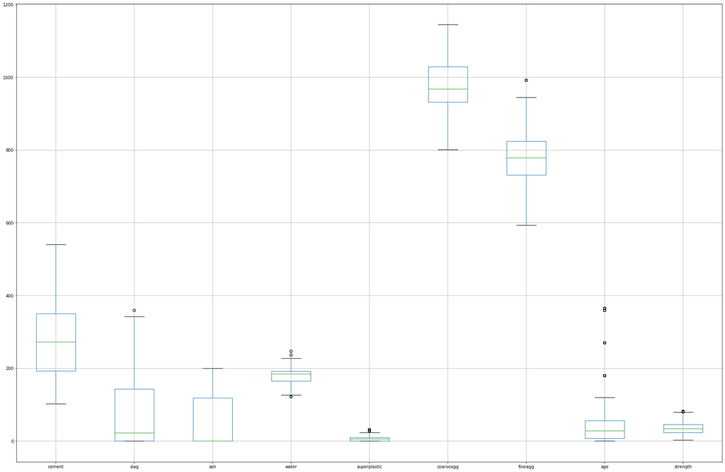

```python
concrete.boxplot(column=['cement','slag','ash','water','superplastic','coarseagg','fineagg','age','strength'],figsize=(30, 20))
```

```python
import random as r
d = [r.random()*1000 for i in range(0,100)]
df = pd.DataFrame({'slag': d})

median = df['slag'].median()
std = df['slag'].std()
outliers = (df['slag'] - median).abs() > std
df[outliers] = np.nan
```

```python
import random as r
d = [r.random()*1000 for i in range(0,100)]
df = pd.DataFrame({'water': d})

median = df['water'].median()
std = df['water'].std()
outliers = (df['water'] - median).abs() > std
df[outliers] = np.nan
```

```python
import random as r
d = [r.random()*1000 for i in range(0,100)]
df = pd.DataFrame({'superplastic': d})

median = df['superplastic'].median()
std = df['superplastic'].std()
outliers = (df['superplastic'] - median).abs() > std
df[outliers] = np.nan
```

```python
import random as r
d = [r.random()*1000 for i in range(0,100)]
df = pd.DataFrame({'fineagg': d})

median = df['fineagg'].median()
std = df['fineagg'].std()
outliers = (df['fineagg'] - median).abs() > std
df[outliers] = np.nan
```

```python
import random as r
d = [r.random()*1000 for i in range(0,100)]
df = pd.DataFrame({'age': d})

median = df['age'].median()
std = df['age'].std()
outliers = (df['age'] - median).abs() > std
df[outliers] = np.nan
df['age'].fillna(median, inplace=True)
```

### PAIRPLOT VISUALIZATION TO UNDERSTAND THE RELATIONSHIP BETWEEN ATTRIBUTES.

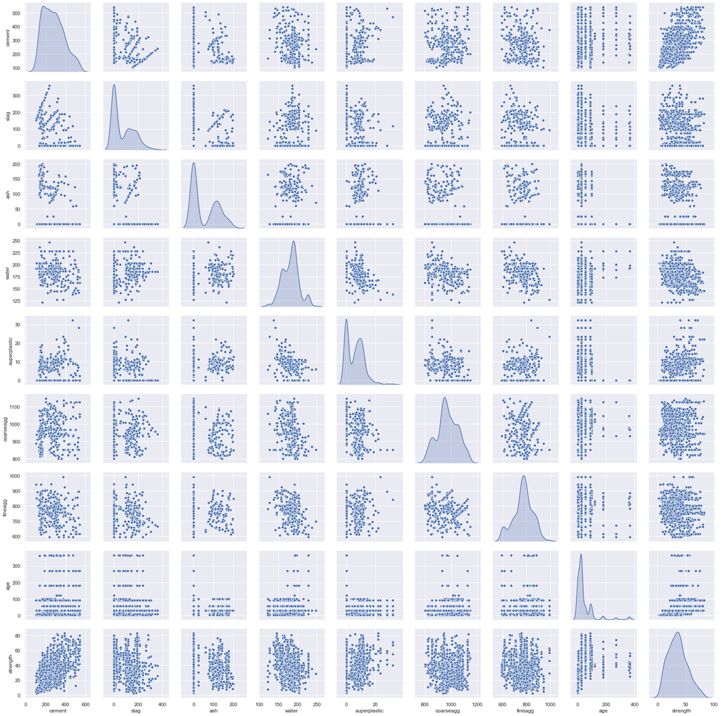

```python
sns.pairplot(concrete, diag_kind="kde")
```

#### The concrete and the Age columns seem to have a postive relationship with the Strength column. All the other attributes do not seem to have any significant relationship. The Fineagg and the Coarseagg columns do not seem to have any kind of relationship with the Strength column. There is clear mix up of gaussians as we can see in the Age column.There are atleast 5 different clusters present in this dataset.

### SCALING THE DATA.

```python
from scipy.stats import zscore

concrete_z = concrete.apply(zscore)

concrete_z.head()
```

|  | cement | slag | ash | water | superplastic | coarseagg | fineagg | age | strength |
| --- | --- | --- | --- | --- | --- | --- | --- | --- | --- |
| 0 | -1.339017 | 1.601441 | -0.847144 | 1.027590 | -1.039143 | -0.014398 | -0.312970 | -0.279733 | -0.355018 |
| 1 | -1.074790 | -0.367541 | 1.096078 | -1.090116 | 0.769617 | 1.388141 | 0.282260 | -0.501465 | -0.737108 |
| 2 | -0.298384 | -0.856888 | 0.648965 | 0.273274 | -0.118015 | -0.206121 | 1.093371 | -0.279733 | -0.395144 |
| 3 | -0.145209 | 0.465044 | -0.847144 | 2.175461 | -1.039143 | -0.526517 | -1.292542 | -0.279733 | 0.600806 |
| 4 | -1.209776 | 1.269798 | -0.847144 | 0.549700 | 0.484905 | 0.958372 | -0.959363 | -0.279733 | -1.049727 |

### SPLITTING OF THE DATA.

```python
from sklearn.model_selection import train_test_split

array = concrete_z.values
X = array[:,0:8]
y = array[:,8]
X_train, X_test, y_train, y_test = train_test_split(X, y, test_size=0.30, random_state=1)
```

### IMPLEMENTING A SVR MODEL.

```python
from sklearn import svm
clr = svm.SVR()
clr.fit(X_train , y_train)
```

```
SVR(C=1.0, cache_size=200, coef0=0.0, degree=3, epsilon=0.1,
    gamma='auto_deprecated', kernel='rbf', max_iter=-1, shrinking=True,
    tol=0.001, verbose=False)
```

```python
y_pred = clr.predict(X_test)
```

```python
clr.score(X_test,y_test)
```

```
0.8294475793675959
```

```python
concrete_z.pop('fineagg')
concrete_z.pop('coarseagg')
concrete_z.head()
```

|  | cement | slag | ash | water | superplastic | age | strength |
| --- | --- | --- | --- | --- | --- | --- | --- |
| 0 | -1.339017 | 1.601441 | -0.847144 | 1.027590 | -1.039143 | -0.279733 | -0.355018 |
| 1 | -1.074790 | -0.367541 | 1.096078 | -1.090116 | 0.769617 | -0.501465 | -0.737108 |
| 2 | -0.298384 | -0.856888 | 0.648965 | 0.273274 | -0.118015 | -0.279733 | -0.395144 |
| 3 | -0.145209 | 0.465044 | -0.847144 | 2.175461 | -1.039143 | -0.279733 | 0.600806 |
| 4 | -1.209776 | 1.269798 | -0.847144 | 0.549700 | 0.484905 | -0.279733 | -1.049727 |

### SPLITTING OF DATA AFTER DROPPING THE ATTRIBUTES.

```python
array = concrete_z.values
X = array[:,0:6]
y = array[:,6]
X_train, X_test, y_train, y_test = train_test_split(X, y, test_size=0.30, random_state=1)
```

### IMPLEMENTING SVR MODEL AGAIN AFTER DROPPING OF ATTRIBUTES.

```python
clr = svm.SVR()
clr.fit(X_train , y_train)
```

```
SVR(C=1.0, cache_size=200, coef0=0.0, degree=3, epsilon=0.1,
    gamma='auto_deprecated', kernel='rbf', max_iter=-1, shrinking=True,
    tol=0.001, verbose=False)
```

```python
y_pred = clr.predict(X_test)
```

```python
clr.score(X_test,y_test)
```

```
0.8436535437038009
```

#### As we can see even after dropping the columns we were able to improve the performance from 82 to 84 by dropping two columns.

#### As we visualised in the pairplot there are mix up of gaussians in the dataset. So we divide the data into clusters using k means clustering.

```python
from sklearn.cluster import KMeans
```

```python
concrete = concrete.loc[:,'cement':'strength']
concrete_z = concrete.apply(zscore)
```

```python
cluster_range = range( 3, 9 )   # expect 3 to four clusters from the pair panel visual inspection hence restricting from 2 to 6
cluster_errors = []
for num_clusters in cluster_range:
  clusters = KMeans( num_clusters, n_init = 5)
  clusters.fit(concrete_z)
  labels = clusters.labels_
  centroids = clusters.cluster_centers_
  cluster_errors.append( clusters.inertia_ )
clusters_df = pd.DataFrame( { "num_clusters":cluster_range, "cluster_errors": cluster_errors } )
clusters_df[0:9]
```

|  | num_clusters | cluster_errors |
| --- | --- | --- |
| 0 | 3 | 6368.751485 |
| 1 | 4 | 5547.746110 |
| 2 | 5 | 4812.917840 |
| 3 | 6 | 4352.347174 |
| 4 | 7 | 4040.499551 |
| 5 | 8 | 3845.050612 |

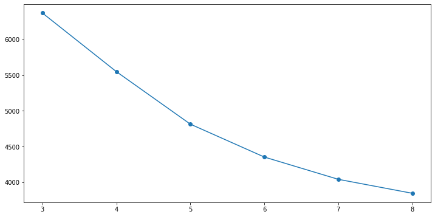

```python
plt.figure(figsize=(12,6))
plt.plot( clusters_df.num_clusters, clusters_df.cluster_errors, marker = "o" )
```

```python
#AS we can see there is sharp elbow at 5 so we take the number of clusters to be 5.
```

```python
cluster = KMeans( n_clusters = 5, random_state = 2354 )
cluster.fit(concrete_z)

prediction=cluster.predict(concrete_z)
concrete_z["GROUP"] = prediction

concrete_z_copy = concrete_z.copy(deep = True)
```

#### To impove the performance we decide to drop the 'fineagg' and 'coarseagg' columns using the pair plot visualisation.

#### Dropping the columns for kmeans clustering.

```python
concrete = concrete.loc[:,'cement':'strength']
concrete_z = concrete.apply(zscore)
concrete_z.pop('fineagg')
concrete_z.pop('coarseagg')
concrete_z.head()
```

|  | cement | slag | ash | water | superplastic | age | strength |
| --- | --- | --- | --- | --- | --- | --- | --- |
| 0 | -1.339017 | 1.601441 | -0.847144 | 1.027590 | -1.039143 | -0.279733 | -0.355018 |
| 1 | -1.074790 | -0.367541 | 1.096078 | -1.090116 | 0.769617 | -0.501465 | -0.737108 |
| 2 | -0.298384 | -0.856888 | 0.648965 | 0.273274 | -0.118015 | -0.279733 | -0.395144 |
| 3 | -0.145209 | 0.465044 | -0.847144 | 2.175461 | -1.039143 | -0.279733 | 0.600806 |
| 4 | -1.209776 | 1.269798 | -0.847144 | 0.549700 | 0.484905 | -0.279733 | -1.049727 |

```python
cluster_range = range( 3, 9 )
cluster_errors = []
for num_clusters in cluster_range:
  clusters = KMeans( num_clusters, n_init = 5)
  clusters.fit(concrete_z)
  labels = clusters.labels_
  centroids = clusters.cluster_centers_
  cluster_errors.append( clusters.inertia_ )
clusters_df = pd.DataFrame( { "num_clusters":cluster_range, "cluster_errors": cluster_errors } )
clusters_df[0:7]
```

|  | num_clusters | cluster_errors |
| --- | --- | --- |
| 0 | 3 | 4443.170913 |
| 1 | 4 | 3655.657043 |
| 2 | 5 | 3017.168717 |
| 3 | 6 | 2744.347056 |
| 4 | 7 | 2557.478248 |
| 5 | 8 | 2367.637873 |

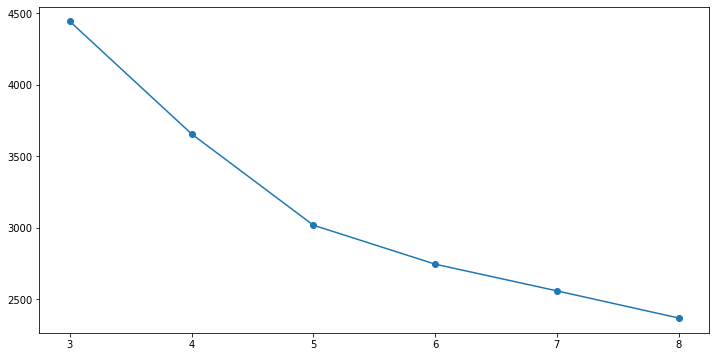

```python
plt.figure(figsize=(12,6))
plt.plot( clusters_df.num_clusters, clusters_df.cluster_errors, marker = "o" )
```

#### AS we can evidently see there is a sharp elbow at 5 again so we restrict the number of clusters to 5.

```python
cluster = KMeans( n_clusters = 5, random_state = 2354 )
cluster.fit(concrete_z)

prediction=cluster.predict(concrete_z)
concrete_z["GROUP"] = prediction

concrete_z_copy = concrete_z.copy(deep = True)
```

### CHECKING THE PRESENCE OF OUTLIERS IN EVERY CLUSTER USING BOXPLOT VISUALIZATION.

```
array([[<matplotlib.axes._subplots.AxesSubplot object at 0x000001FC864555C8>,
      dtype=object)
```

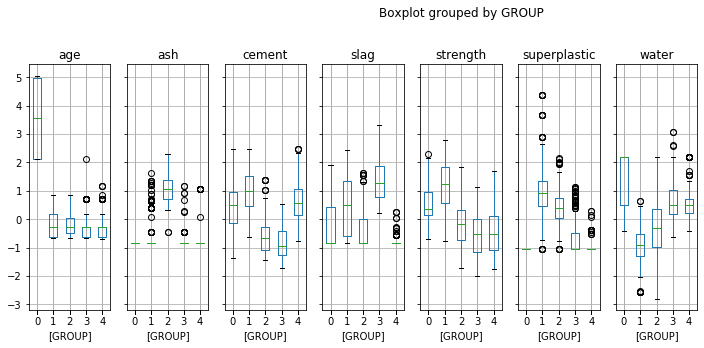

```python
import matplotlib.pylab as plt

concrete_z.boxplot(by = 'GROUP',  layout=(2,9), figsize=(15, 10))
```

#### As we can see outliers are present in every single attribute so we try to replace it with the medians of that particular attribute.

```python
data = concrete_z
def replace(group):
    median, std = group.median(), group.std()  #Get the median and the standard deviation of every group
    outliers = (group - median).abs() > 2*std # Subtract median from every member of each group. Take absolute values > 2std
    group[outliers] = group.median()
    return group

data_corrected = (data.groupby('GROUP').transform(replace))
concat_data = data_corrected.join(pd.DataFrame(concrete_z['GROUP']))
```

```
array([[<matplotlib.axes._subplots.AxesSubplot object at 0x000001FC865E90C8>,
      dtype=object)
```

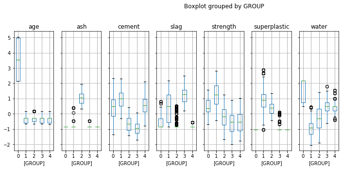

```python
concat_data.boxplot(by = 'GROUP', layout=(2,9), figsize=(15, 10))
```

### We are not able to replace all the outliers though we have seemes to suprress most of the outliers .

### VISUALIZATION OF SPREAD OF DATA IN INDIVIDUAL CLUSTER.

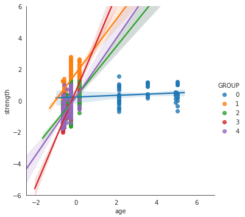

```python
var = 'age'

with sns.axes_style("white"):
    plot = sns.lmplot(var,'strength',data=concat_data,hue='GROUP')
plot.set(ylim = (-6,6))
```

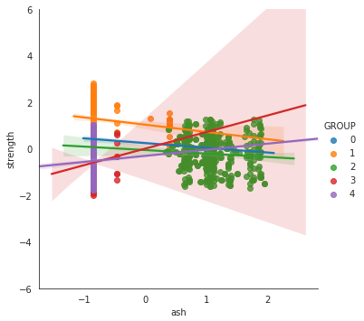

```python
var = 'ash'

with sns.axes_style("white"):
    plot = sns.lmplot(var,'strength',data=concat_data,hue='GROUP')
plot.set(ylim = (-6,6))
```

#### The data points are distributed in a very uneven fashion , hence we cannot conclude any relationship of the ash attribute with the strength column.

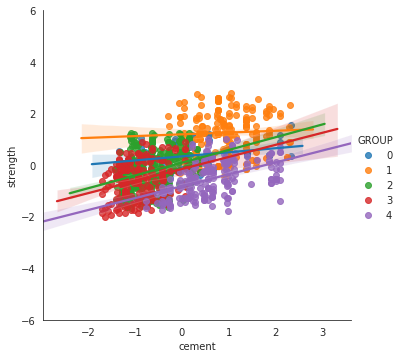

```python
var = 'cement'

with sns.axes_style("white"):
    plot = sns.lmplot(var,'strength',data=concat_data,hue='GROUP')
plot.set(ylim = (-6,6))
```

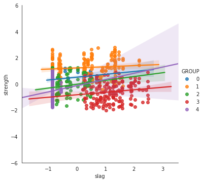

```python
var = 'slag'

with sns.axes_style("white"):
    plot = sns.lmplot(var,'strength',data=concat_data,hue='GROUP')
plot.set(ylim = (-6,6))
```

#### All the clusters seem to be distributed in an uneven pattern.

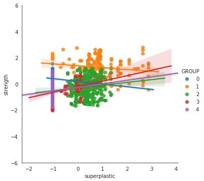

```python
var = 'superplastic'

with sns.axes_style("white"):
    plot = sns.lmplot(var,'strength',data=concat_data,hue='GROUP')
plot.set(ylim = (-6,6))
```

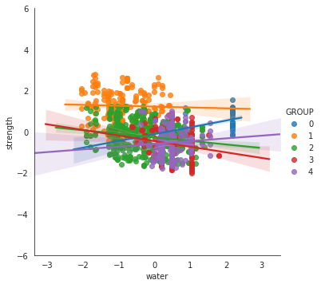

```python
var = 'water'

with sns.axes_style("white"):
    plot = sns.lmplot(var,'strength',data=concat_data,hue='GROUP')
plot.set(ylim = (-6,6))
```

#### All the clusters seem to be distributed in an uneven pattern.

### IMPLEMENTING PCA.

```python
data = concrete.loc[:,'cement':'strength']
data_z = concrete.apply(zscore)
```

```python
covMatrix = np.cov(data_z,rowvar=False)
print(covMatrix)
```

```
[[ 1.00097182 -0.27548337 -0.39785361 -0.08166604  0.09247596 -0.10945526
  -0.22293429  0.08202566  0.49831572]
 [-0.27548337  1.00097182 -0.32389436  0.10735626  0.04331247 -0.28427461
  -0.28187634 -0.04428902  0.13496029]
 [-0.39785361 -0.32389436  1.00097182 -0.25723376  0.37787001 -0.00997051
   0.07918537 -0.15452054 -0.10585769]
 [-0.08166604  0.10735626 -0.25723376  1.00097182 -0.65817191 -0.18247076
  -0.45109913  0.27788802 -0.28991486]
 [ 0.09247596  0.04331247  0.37787001 -0.65817191  1.00097182 -0.26625765
   0.22290765 -0.1928873   0.36643459]
 [-0.10945526 -0.28427461 -0.00997051 -0.18247076 -0.26625765  1.00097182
  -0.17865441 -0.00301881 -0.1650949 ]
 [-0.22293429 -0.28187634  0.07918537 -0.45109913  0.22290765 -0.17865441
   1.00097182 -0.1562464  -0.16740378]
 [ 0.08202566 -0.04428902 -0.15452054  0.27788802 -0.1928873  -0.00301881
  -0.1562464   1.00097182  0.32919261]
 [ 0.49831572  0.13496029 -0.10585769 -0.28991486  0.36643459 -0.1650949
  -0.16740378  0.32919261  1.00097182]]
```

```python
from sklearn.decomposition import PCA
pca = PCA(n_components=8)
pca.fit(data_z)
```

```
PCA(copy=True, iterated_power='auto', n_components=8, random_state=None,
    svd_solver='auto', tol=0.0, whiten=False)
```

```python
print(pca.explained_variance_)
```

```
[2.29012322 1.93822536 1.41026096 1.04383811 1.01514443 0.8481947
 0.28713483 0.14704291]
```

```python
print(pca.components_)
```

```
[[ 4.13267471e-02  1.63042739e-01 -3.69899564e-01  5.64021863e-01
  -5.36018387e-01  6.02738613e-02 -3.81763152e-01  2.61941268e-01
  -1.07041270e-01]
 [ 5.36485954e-01  1.36147699e-01 -2.68270482e-01 -1.18457734e-01
   2.48248754e-01 -2.24761035e-01 -1.86860187e-01  2.51768129e-01
   6.30235236e-01]
 [ 3.59693365e-01 -6.99055619e-01  1.98043268e-02 -1.20189288e-01
  -1.87966815e-01  5.49480030e-01  1.25812636e-03  1.69505840e-01
   3.33258025e-02]
 [ 3.09813343e-01 -7.59934879e-02 -6.00689663e-01 -4.72149236e-02
  -1.65929475e-01 -2.21421137e-01  5.27531844e-01 -3.59982355e-01
  -2.25269414e-01]
 [-5.44413593e-02 -3.62650227e-01  2.27237640e-01  2.96091761e-01
  -3.70769171e-02 -5.45674811e-01  3.84793718e-01  5.28215631e-01
   1.41465635e-04]
 [-3.89824821e-01  2.70156315e-01 -3.20385015e-01 -3.06016015e-01
  -8.26508492e-02  3.47660170e-01  4.09180653e-01  5.09896072e-01
   1.53747350e-01]
 [ 1.33851817e-01 -4.94798767e-03 -2.47325097e-01  1.00896687e-02
   6.14074852e-01  5.96959024e-02 -1.74760168e-01  3.43390997e-01
  -6.25841582e-01]
 [ 2.98253891e-01  2.28769298e-01  2.55347236e-01 -5.85652817e-01
  -4.47332284e-01 -2.42939734e-01 -1.40389401e-01  2.26235878e-01
  -3.47131168e-01]]
```

```python
print(pca.explained_variance_ratio_)
```

```
[0.25421109 0.21514929 0.15654353 0.11586941 0.11268432 0.09415236
 0.0318729  0.01632224]
```

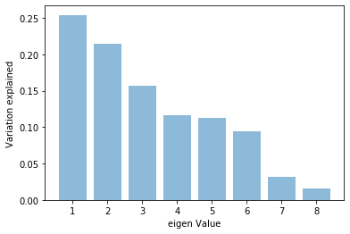

```python
plt.bar(list(range(1,9)),pca.explained_variance_ratio_,alpha=0.5, align='center')
plt.ylabel('Variation explained')
plt.xlabel('eigen Value')
plt.show()
```

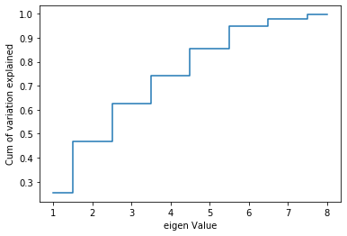

```python
plt.step(list(range(1,9)),np.cumsum(pca.explained_variance_ratio_), where='mid')
plt.ylabel('Cum of variation explained')
plt.xlabel('eigen Value')
plt.show()
```

#### we can see there is a sharp elbow around x=6, so we take n_components = 6.

### DIMENSIONALITY REDUCTION

```python
pca2 = PCA(n_components=6)
pca2.fit(data)
print(pca2.components_)
print(pca2.explained_variance_ratio_)
Xpca = pca2.transform(data)
```

```
[[ 0.90443974 -0.25467084 -0.23937562  0.00542035 -0.00112053 -0.01281057
  -0.21226345  0.10031213  0.06721449]
 [ 0.02306241  0.78881234 -0.29906341  0.07548306 -0.00487303 -0.27609068
  -0.44648591  0.07000456  0.04008098]
 [ 0.15204486  0.07144972 -0.04889159 -0.04206219  0.02418344 -0.75985985
   0.61268308 -0.11771877  0.02018896]
 [-0.01348223 -0.20068135  0.68623788  0.07578572  0.02037147 -0.47859717
  -0.48052483  0.14663614  0.03166714]
 [-0.1537579  -0.10133729 -0.18780743  0.09396764 -0.02279073 -0.0620411
   0.1456254   0.94572822  0.0448394 ]
 [-0.2767579  -0.43389252 -0.49544777  0.46788057 -0.10139455 -0.27528078
  -0.25561273 -0.20429824 -0.27861376]]
[0.32491298 0.24752015 0.18357202 0.10700227 0.10043506 0.03194579]
```

```python
Xpca
```

```
array([[-145.40812225,  133.63710594,  -22.37859147,  -51.66982697,
          -0.66228787,   28.50454353],
       [-120.56848503,  -92.93179459,  -86.30963089,  -13.21544541,
         -28.87929284,  -26.84704722],
       [ -39.88322953, -107.17873886,   55.49039805,    6.92869303,
           1.80268826,   10.38207503],
       ...,
       [ -22.45781553,   51.98877817,   77.80849573,   65.72607299,
         -21.27607301,   -5.12978614],
       [ 123.6983247 ,   66.84921455,  -51.1589475 ,   75.45196909,
         209.44587734,   34.4884974 ],
       [ 295.23657672,   -9.05607002, -172.1210472 ,  -27.38206304,
         -91.42654837,  -13.70130886]])
```

### PAIRPLOT VISUALISATION ON THE PCA DATA.

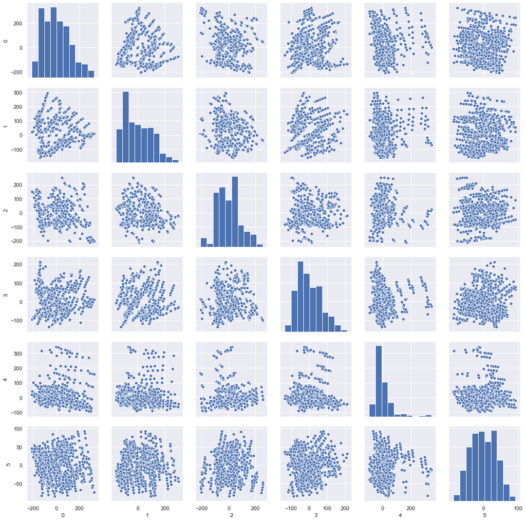

```python
sns.pairplot(pd.DataFrame(Xpca))
```

### IMPLEMENTING SVR MODEL ON THE PCA DATASET.

### SPLITTING OF PCA DATA.

```python
X,y = np.array(Xpca)[ :, 0:5], np.array(data['strength'])[:]  #Note that the X variable contains PCA data
x_train, x_test, y_train, y_test = train_test_split(X, y, test_size=0.3, random_state=1)
```

```python
clr = svm.SVR()
clr.fit(x_train , y_train)
```

```
SVR(C=1.0, cache_size=200, coef0=0.0, degree=3, epsilon=0.1,
    gamma='auto_deprecated', kernel='rbf', max_iter=-1, shrinking=True,
    tol=0.001, verbose=False)
```

```python
y_pred = clr.predict(x_test)
```

```python
clr.score(x_test,y_test)
```

```
0.020550574028229573
```

#### As we can see even after applying pca the model performance drops down. Try other models to get the desired performance.

### EXTRACTING THE FEATURE IMPORTANCE OF ALL THE ATTRIBUTES USING DECISION TREE REGRESSOR.

```python
from sklearn.tree import DecisionTreeRegressor
```

```python
concrete = concrete.loc[:,'cement':'strength']
concrete_z = concrete.apply(zscore)

array = concrete.values
X = array[:,0:8]
y = array[:,8]
X_train, X_test, y_train, y_test = train_test_split(X, y, test_size=0.30, random_state=1)
```

```python
regressor = DecisionTreeRegressor(random_state=0, max_depth=3)

regressor.fit(X_train , y_train)
feature_importances = regressor.feature_importances_


feature_names = concrete.columns[0:9]
print(feature_names)

k = 8

print(feature_importances)
top_k_idx = (feature_importances.argsort()[-k:][::-1])

print(feature_names[top_k_idx], feature_importances)
```

```
Index(['cement', 'slag', 'ash', 'water', 'superplastic', 'coarseagg',
       'fineagg', 'age', 'strength'],
      dtype='object')
[0.46405785 0.         0.         0.08815856 0.         0.
 0.         0.44778359]
Index(['cement', 'age', 'water', 'fineagg', 'coarseagg', 'superplastic', 'ash',
       'slag'],
      dtype='object') [0.46405785 0.         0.         0.08815856 0.         0.
 0.         0.44778359]
```

```python
y_pred = regressor.predict(X_test)
```

```python
regressor.score(X_test,y_test)
```

```
0.583104124329016
```

```python
X = data.drop( ['strength','age', 'water', 'coarseagg', 'superplastic', 'ash' ] , axis=1)
y = data['strength']

X_train, X_test, y_train, y_test = train_test_split(X, y, test_size=0.30, random_state=1)
```

```python
regressor = DecisionTreeRegressor(random_state=0, max_depth=3)
regressor.fit(X_train , y_train)
y_pred = regressor.predict(X_test)

regressor.feature_importances_

print (pd.DataFrame(regressor.feature_importances_, columns = ["Imp"], index = X_train.columns))
```

```
              Imp
cement   0.742356
slag     0.214487
fineagg  0.043157
```

```python
y_pred = regressor.predict(X_test)
```

```python
regressor.score(X_test,y_test)
```

```
0.29293622461412916
```

#### As we can see after dropping the columns we were not able to increase the performance even a bit rather it has been decreased.

### IMPLEMENTING REGULARIZATIONTECHNIQUES FOR BETTER PERFORMANCE.

### IMPORTING REQUIRED LIBRARIES.

```python
from sklearn.linear_model import LinearRegression
from sklearn.linear_model import Ridge
from sklearn.linear_model import Lasso
from sklearn.preprocessing import PolynomialFeatures
from sklearn.metrics import r2_score
```

#### Scaling the data.

```python
concrete_z=concrete.apply(zscore)
```

```python
X = concrete_z.drop("strength" , axis=1)
y = concrete_z[['strength']]
```

#### Splitting of the data.

```python
X_train, X_test, y_train, y_test = train_test_split(X, y, test_size=.30, random_state=1)
```

### IMPLEMENTING A LINEAR MODEL.

```python
regression_model = LinearRegression()
regression_model.fit(X_train, y_train)
```

```
LinearRegression(copy_X=True, fit_intercept=True, n_jobs=None, normalize=False)
```

### IMPLEMENTING A RIDGE MODEL.

```python
ridge = Ridge(alpha=.3)
ridge.fit(X_train,y_train)
print ("Ridge model:", (ridge.coef_))
```

```
Ridge model: [[ 0.78652136  0.55696657  0.34291358 -0.13534196  0.13450497  0.10831507
   0.16918324  0.41713594]]
```

### IMPLEMENTING A LASSO MODEL.

```python
lasso = Lasso(alpha=0.1)
lasso.fit(X_train,y_train)
print ("Lasso model:", (lasso.coef_))
```

```
Lasso model: [ 0.39456594  0.14777481  0.         -0.11823668  0.19361099 -0.
 -0.          0.2543608 ]
```

### COMPARING THE ACCURACY OF THE MODELS.

```python
print(regression_model.score(X_train, y_train))
print(regression_model.score(X_test, y_test))
```

```
0.6031487540630229
0.6339136715208273
```

```python
print(ridge.score(X_train, y_train))
print(ridge.score(X_test, y_test))
```

```
0.6031447909390979
0.6340333563625516
```

```python
print(lasso.score(X_train, y_train))
print(lasso.score(X_test, y_test))
```

```
0.5215627623725142
0.51856614888699
```

#### As we can see all the three models do not perform well.

### IMPLEMENTING POLYNOMIAL FUNCTIONS FOR BETTER PERFORMANCE.

```python
poly = PolynomialFeatures(degree = 2, interaction_only=True) #With degree 2 we get the right fit model.
```

#### Splitting the data into training and test sets using polynomial data.

```python
X_poly = poly.fit_transform(X)
X_train, X_test, y_train, y_test = train_test_split(X_poly, y, test_size=0.30, random_state=1)
X_train.shape
```

```
(721, 37)
```

### IMPLEMENT ALTHREE MODELS AGAIN USING POLYNOMIAL DATA.

```python
regression_model = LinearRegression()
regression_model.fit(X_train, y_train)
```

```
LinearRegression(copy_X=True, fit_intercept=True, n_jobs=None, normalize=False)
```

```python
ridge = Ridge(alpha=.3)
ridge.fit(X_train,y_train)
print ("Ridge model:", (ridge.coef_))
```

```
Ridge model: [[ 0.          0.79789983  0.59817277  0.35454569 -0.10043205  0.25413605
   0.06869811  0.14391004  0.89499721  0.04494582  0.06933944 -0.23091287
  -0.10306118  0.02006644  0.03696231  0.16552383  0.10451967 -0.09635672
   0.03169231  0.02142904  0.12410393  0.24855655 -0.13578623 -0.13939461
   0.01602145  0.11882556  0.39554324  0.11802821 -0.06457404 -0.01853773
  -0.0622421   0.1060091   0.05914165  0.14582765  0.09763806 -0.01903997
   0.10403346]]
```

```python
lasso = Lasso(alpha=0.01)
lasso.fit(X_train,y_train)
print ("Lasso model:", (lasso.coef_))
```

```
Lasso model: [ 0.          0.5982949   0.36677867  0.13682949 -0.21606102  0.24419964
 -0.02879967  0.          0.80695533  0.          0.         -0.0819083
 -0.08457494  0.          0.00555156 -0.          0.00653393 -0.
  0.01971096 -0.          0.07901129  0.11142476 -0.         -0.12927781
  0.          0.06680382  0.20768799  0.06925353 -0.03296183 -0.
 -0.08112706  0.06850623  0.00202811  0.19692948  0.08041086 -0.
 -0.        ]
```

### COMPARING THE ACCURACY OF THE MODELS AGAIN.

```python
print(regression_model.score(X_train, y_train))
print(regression_model.score(X_test, y_test))
```

```
0.7549578268848258
0.7444710081439014
```

```python
print(ridge.score(X_train, y_train))
print(ridge.score(X_test, y_test))
```

```
0.7549463250929687
0.7444379607063953
```

```python
print(lasso.score(X_train, y_train))
print(lasso.score(X_test, y_test))
```

```
0.7388362003903456
0.725166545153265
```

#### As we can clearly see the accuracy of all the models have shooted up with polynomial data. Linear and Ridge models give us almost same accuracy of 75% ,though Lasso lacks little behind with 73% accuracy.

```python
from sklearn.model_selection import KFold
from sklearn.model_selection import cross_val_score
```

```python
num_folds=80
seed=7

kfold=KFold(n_splits=num_folds, random_state=seed)
model= Ridge()
results=cross_val_score(model,X,y, cv=kfold)
print(results)
print("accuracy: %.3f%% (%.3f%%)" % (results.mean()*100.0,results.std()*100.0))
```

```
[ 0.13096209  0.05827749  0.61937453  0.25502583  0.15909334  0.23873438
  0.59454647  0.69178769  0.6653572   0.65959629  0.49998076  0.34731874
  0.63573211  0.66861601  0.65684921  0.80231645  0.70122453  0.70660809
  0.81228903  0.78059954  0.67056517  0.48651715  0.52537884  0.6715632
  0.67188241  0.41862593 -1.07307978  0.3632418   0.74408475  0.58980104
  0.67646224  0.72628588  0.76572514  0.76675713  0.4122506   0.18665302
  0.73716847  0.45818404  0.01425043  0.38028625  0.67289785  0.61486188
  0.64037783  0.73073032  0.86859767  0.59524634  0.50219458  0.80853508
  0.3511509   0.65818947  0.75718741  0.57704902  0.40720613  0.70896709
  0.56452173  0.26063718  0.66468517  0.6848531   0.13462705  0.76107573
  0.16658268  0.57003748  0.85963341  0.49851435  0.49671597  0.13938407
  0.62752574  0.7225171   0.61240239 -0.56631318  0.5254617   0.72982503
  0.65370842 -0.07389711  0.63845058  0.20333237  0.40215318  0.73862567
  0.52921434  0.54837695]
accuracy: 51.078% (30.508%)
```